# Reliability and Validity of Dust Measures

Richard E. Lucas, Vicki A. Freedman, Jennifer C. Cornman, Deborah Carr

2017-03-08

I used the data Jen provided, where activities were arranged by whether they occurred on a weekday or weekend (e.g., Activity 1 is the first activity on the weekend, Activity 2 is the second activity on the weekend, Activity 6 is the third activity on the weekday). Descriptive statistics at the activity level and person level are reported below (I decided to keep these in their original metric). As can be seen, the means for the positive emotion variables are extremely high, the means for the negative emotion variables are extremely low, and the means for tiredness and pain are slightly higher than the negative emotion variables. The ‘wb’ variable is just the five emotion items; the ‘pa’ variable is calm and happiness; the ‘na’ variable is frustrated, worried, and sad; and the ‘som’ variable is tired and pain.

Descriptive Data For DRM Adjectives and Constructed Scale Scores at the activity level.

|  | n | mean | sd | median | min | max | skew |
| --- | --- | --- | --- | --- | --- | --- | --- |
| calm | 9670 | 5.31 | 1.22 | 6.0 | 0 | 6 | -2.36 |
| happy | 9670 | 5.01 | 1.23 | 5.0 | 0 | 6 | -1.63 |
| frustrated | 9670 | 0.90 | 1.60 | 0.0 | 0 | 6 | 1.71 |
| worried | 9670 | 0.61 | 1.34 | 0.0 | 0 | 6 | 2.38 |
| sad | 9670 | 0.46 | 1.22 | 0.0 | 0 | 6 | 2.87 |
| pain | 9670 | 1.07 | 1.67 | 0.0 | 0 | 6 | 1.44 |
| tired | 9670 | 1.70 | 1.89 | 1.0 | 0 | 6 | 0.73 |
| wb | 9670 | 5.27 | 0.98 | 5.6 | 0 | 6 | -1.81 |
| pa | 9670 | 5.16 | 1.06 | 5.5 | 0 | 6 | -1.80 |
| na | 9670 | 0.66 | 1.14 | 0.0 | 0 | 6 | 2.08 |
| som | 9670 | 1.38 | 1.51 | 1.0 | 0 | 6 | 1.00 |

Descriptive Data For DRM Adjectives and Constructed Scale Scores at the person level.

|  | n | mean | sd | median | min | max | skew |
| --- | --- | --- | --- | --- | --- | --- | --- |
| calm | 1772 | 5.30 | 0.75 | 5.50 | 0.00 | 6.0 | -1.47 |
| happy | 1772 | 5.02 | 0.87 | 5.17 | 1.00 | 6.0 | -0.97 |
| frustrated | 1772 | 0.90 | 1.00 | 0.67 | 0.00 | 6.0 | 1.37 |
| worried | 1772 | 0.61 | 0.94 | 0.17 | 0.00 | 5.5 | 2.07 |
| sad | 1772 | 0.47 | 0.89 | 0.00 | 0.00 | 6.0 | 2.65 |
| pain | 1772 | 1.11 | 1.49 | 0.40 | 0.00 | 6.0 | 1.41 |
| tired | 1772 | 1.72 | 1.43 | 1.50 | 0.00 | 6.0 | 0.71 |
| wb | 1772 | 5.27 | 0.72 | 5.47 | 0.93 | 6.0 | -1.64 |
| pa | 1772 | 5.16 | 0.73 | 5.25 | 1.17 | 6.0 | -1.03 |
| na | 1772 | 0.66 | 0.84 | 0.36 | 0.00 | 5.6 | 2.05 |
| som | 1772 | 1.41 | 1.28 | 1.17 | 0.00 | 6.0 | 1.07 |

These variables are not weighted by time spent in activity or by the number of days in the week or weekend. This is something we could do, but in our other work (with the GSOEP and our own community data), weighting didn’t really make much difference.

The table below reports the correlations among the various items. In the Lee et al. (2016) paper, they separated by activity level and person level. However, using the raw activity-level data conflates within- and between-person associations; so here, I look specifically at the within- and between-person levels. The within-person correlations are above the diagonal; the between-person correlations are below the diagonal.

Lee, Yoonjoo, Sandra L. Hofferth, Sarah M. Flood, and Kimberly Fisher. 2016. “Reliability, Validity, and Variability of the Subjective Well-Being Questions in the 2010 American Time Use Survey.” *Social Indicators Research* 126 (3): 1355–73. doi:10.1007/s11205-015-0923-8.

Correlations Among Items from the DUST DRM. Correlations above the diagonal reflect within-person correlations; correlations below the diagonal reflect between-person correlations.

|  | Calm | Happy | Frustrated | Worried | Sad | Pain | Tired |
| --- | --- | --- | --- | --- | --- | --- | --- |
| Calm | 1.000 | 0.445 | -0.329 | -0.244 | -0.187 | -0.089 | -0.086 |
| Happy | 0.714 | 1.000 | -0.352 | -0.276 | -0.277 | -0.126 | -0.129 |
| Frustrated | -0.728 | -0.595 | 1.000 | 0.400 | 0.300 | 0.111 | 0.128 |
| Worried | -0.644 | -0.526 | 0.844 | 1.000 | 0.453 | 0.097 | 0.087 |
| Sad | -0.532 | -0.503 | 0.749 | 0.853 | 1.000 | 0.108 | 0.102 |
| Pain | -0.288 | -0.269 | 0.395 | 0.402 | 0.404 | 1.000 | 0.269 |
| Tired | -0.438 | -0.372 | 0.485 | 0.494 | 0.435 | 0.585 | 1.000 |

I used Mplus to run a multilevel exploratory factor analysis, first using all seven items and then using just the five emotion items. Scree plots for the first analyses are reported below, separately for the between- and within-person levels. Consistent with the correlations, there is a stronger first factor for the between-person data.

The results are somewhat ambiguous when all seven items are included. There is a strong first factor, and two factors that pass the eigen-value-greater-than-one threshold. However, it is less clear whether there is a break after one or three factors.

Scree Plot for All Seven Ratings

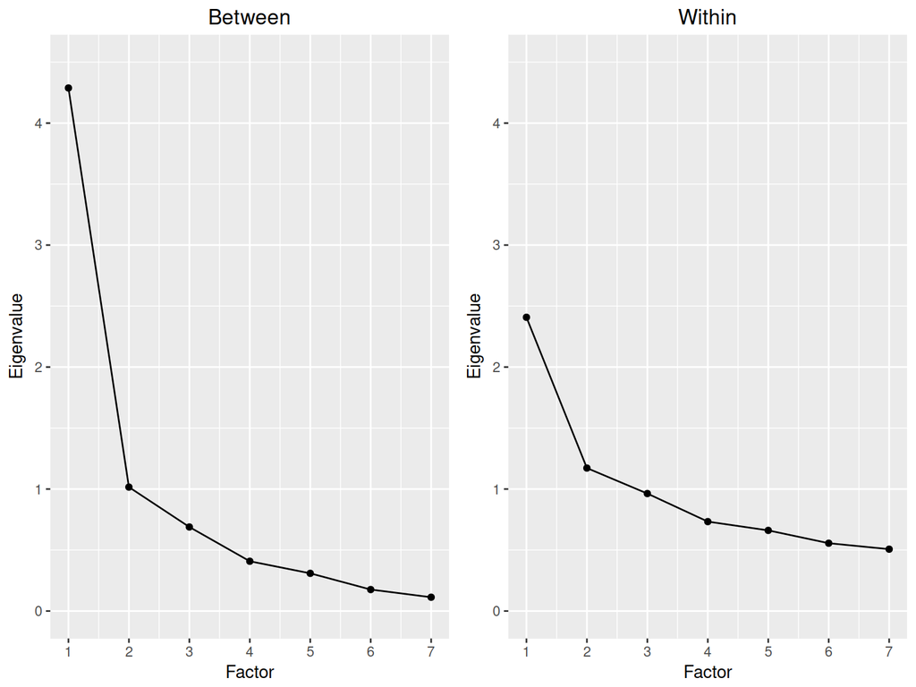

Importantly, when I tried to extract and rotate one to three factors, there were often estimation problems, especially when extracting two between-person factors. When looking at results just for the emotion items, things get a little clearer, with a clear single-factor dominating:

Scree Plot for Five Affect Ratings

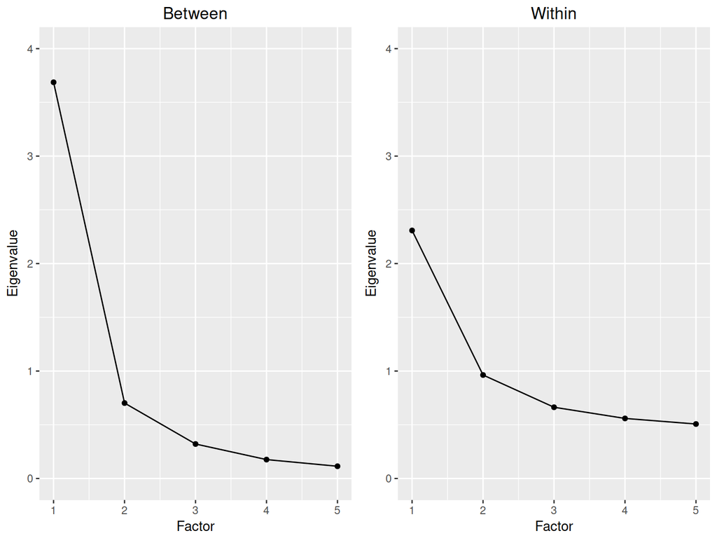

We can look at the reliability of the scale scores. The Cronbach’s alpha for all five items at the between person level is 0.91. At the within-person level, the alpha is 0.71. For just the positive affect scale, the between- and within-person alphas are:0.83 and 0.62. For the negative affect scale, the between- and within-person alphas are: 0.93 and 0.65. Finally, for the two somatic items, the between- and within-person alphas are: 0.74 and 0.42.

We can also calculate alphas for each scale within an activity. The average alphas for the total score, positive affect, negative affect, and somatic scales are: 0.78, 0.58, 0.72, and 0.54 , respectively.

Another way to think about reliability is how stable these are over short periods of time (e.g., from the weekend report to the weekday). So I aggregated across the three activities within each day and calculated stability of the scale scores, which are reported below.

Correlations between weekday (0) and weekend (1) reports of the DRM-based scale scores for overall well-being, positive affect, negative affect, and somatic scores.

|  | wb0 | pa0 | na0 | som0 | wb1 | pa1 | na1 | som1 |
| --- | --- | --- | --- | --- | --- | --- | --- | --- |
| wb0 | 1.00 | 0.81 | -0.94 | -0.42 | 0.52 | 0.41 | -0.49 | -0.32 |
| pa0 | 0.81 | 1.00 | -0.57 | -0.31 | 0.43 | 0.45 | -0.34 | -0.25 |
| na0 | -0.94 | -0.57 | 1.00 | 0.41 | -0.48 | -0.32 | 0.49 | 0.31 |
| som0 | -0.42 | -0.31 | 0.41 | 1.00 | -0.28 | -0.20 | 0.28 | 0.61 |
| wb1 | 0.52 | 0.43 | -0.48 | -0.28 | 1.00 | 0.81 | -0.94 | -0.43 |
| pa1 | 0.41 | 0.45 | -0.32 | -0.20 | 0.81 | 1.00 | -0.55 | -0.32 |
| na1 | -0.49 | -0.34 | 0.49 | 0.28 | -0.94 | -0.55 | 1.00 | 0.41 |
| som1 | -0.32 | -0.25 | 0.31 | 0.61 | -0.43 | -0.32 | 0.41 | 1.00 |

Stabilities are only moderate, even for the constructed scale scores. This may mean that (a) three activities does not lead to a reliable estimate of daily experiential well-being or (b) there is reliable day-level variance that changes from day to day. Our prior work on the year-to-year stability actually found higher levels of stability even over a year (Hudson, Lucas, and Donnellan 2016).

Hudson, Nathan W., Richard E. Lucas, and M. Brent Donnellan. 2016. “Day-to-Day Affect Is Surprisingly Stable: A Two-Year Longitudinal Study of Well-Being.” *Social Psychological and Personality Science*.

# Issues

- Weight by length of activity or number of days when creating person-level scale scores?
- Use any criterion variables as tests of validity? The ATUS study used health, but we could also use life satisfaction, personality, etc. We could also look at these predictors within and between persons.
- Any better arguments for one versus two factors? How should we explain the difficulties we encountered when conducting the EFA?
- Is this enough?